# Practical Machine Learning Project

Ting Xu

1/24/2021

## Background

Using devices such as Jawbone Up, Nike FuelBand, and Fitbit it is now possible to collect a large amount of data about personal activity relatively inexpensively. These type of devices are part of the quantified self movement a group of enthusiasts who take measurements about themselves regularly to improve their health, to find patterns in their behavior, or because they are tech geeks. One thing that people regularly do is quantify how much of a particular activity they do, but they rarely quantify how well they do it. In this project, your goal will be to use data from accelerometers on the belt, forearm, arm, and dumbell of 6 participants. They were asked to perform barbell lifts correctly and incorrectly in 5 different ways. More information is available from the website here: http://groupware.les.inf.puc-rio.br/har (see the section on the Weight Lifting Exercise Dataset).

## Data Checking

The training data for this project are available here:

https://d396qusza40orc.cloudfront.net/predmachlearn/pml-training.csv

The test data are available here:

https://d396qusza40orc.cloudfront.net/predmachlearn/pml-testing.csv

Loading data:

```r
training = read.csv("./pml-training.csv",na.strings=c("NA","#DIV/0!",""))
testing = read.csv("./pml-testing.csv",na.strings=c("NA","#DIV/0!",""))
```

First look at the data:

```r
# Data dimensions
dim(training)
```

```
## [1] 19622   160
```

```r
dim(testing)
```

```
## [1]  20 160
```

## Cross-validation will be performed by spliting the training dataset

```r
# load packages
library(caret)
library(randomForest)
```

First we index for training dataset and testing dataset from the pml-training data set:

1. A training dataset, containing 70% of the observations. The models for prediction will be built using this dataset.
2. A testing dataset, containing 30% of the observations. The accuracy of our prediction models will be evaluated using this dataset.

```r
set.seed(12345)
inTrain = createDataPartition(y=training$classe,p=0.7, list=FALSE)
# training dataset
df.train = training[inTrain,]
# testing dataset
df.test = training[-inTrain,]
```

We total have 160 variables. However, not all variables are relevent in the prediction. Therefore, we will have to perform data cleaning, where we are going to remove the NA’s, the Near Zero Variance(NZR), and the ID variables.

```r
# remove columns only contain NA's
df.train <- df.train[, colSums(is.na(df.train)) == 0]
df.test <- df.test[, colSums(is.na(df.test)) == 0]
# remove the Near Zero Variance columns
NZV <- nearZeroVar(df.train)
df.train <- df.train[,-NZV]
df.test <- df.test[,-NZV]
# remove ID variables
df.train <- df.train[,-(1:5)]
df.test <- df.test[,-(1:5)]
# check dimention
dim(df.train)
```

```
## [1] 13737    54
```

```r
dim(df.test)
```

```
## [1] 5885   54
```

After data cleaning, we will have 54 variables for the analysis.

## Build prediction model

#### Frist we conduct the prediction model with Random Forest.

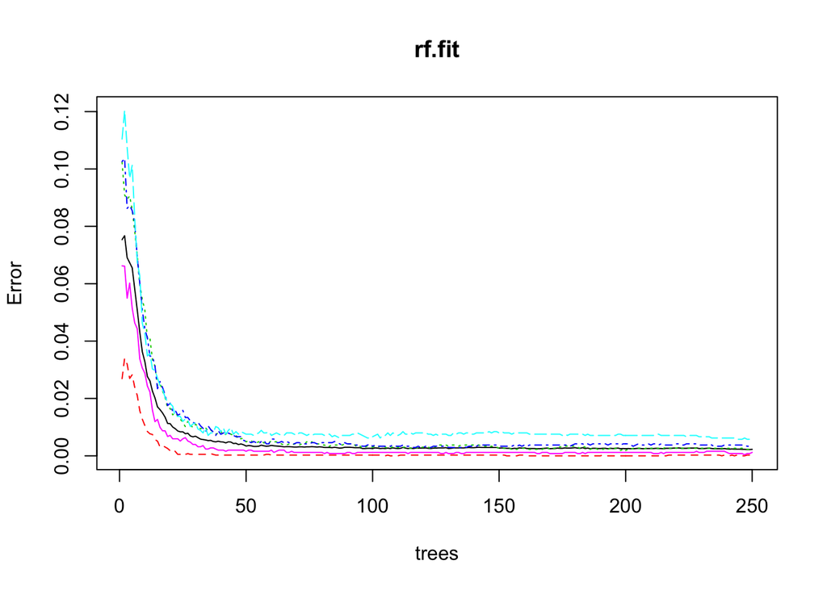

```r
# Build model
set.seed(12345)
rf.fit = randomForest(
  classe ~ .,
  data = df.train,
  ntree = 250)
# Plot the Random Forests model
plot(rf.fit)
```

Then we predict using random forest.

```r
# Predict with random forest model
pred.rf <- predict(rf.fit, df.test)
# Get results (Accuracy, etc.)
result.rf <- confusionMatrix(pred.rf, df.test$classe)
result.rf
```

```
## Confusion Matrix and Statistics
##
##           Reference
## Prediction    A    B    C    D    E
##          A 1674    1    0    0    0
##          B    0 1138    2    0    0
##          C    0    0 1024    7    0
##          D    0    0    0  957    1
##          E    0    0    0    0 1081
##
## Overall Statistics
##
##                Accuracy : 0.9981
##                  95% CI : (0.9967, 0.9991)
##     No Information Rate : 0.2845
##     P-Value [Acc > NIR] : < 2.2e-16
##
##                   Kappa : 0.9976
##
##  Mcnemar's Test P-Value : NA
##
## Statistics by Class:
##
##                      Class: A Class: B Class: C Class: D Class: E
## Sensitivity            1.0000   0.9991   0.9981   0.9927   0.9991
## Specificity            0.9998   0.9996   0.9986   0.9998   1.0000
## Pos Pred Value         0.9994   0.9982   0.9932   0.9990   1.0000
## Neg Pred Value         1.0000   0.9998   0.9996   0.9986   0.9998
## Prevalence             0.2845   0.1935   0.1743   0.1638   0.1839
## Detection Rate         0.2845   0.1934   0.1740   0.1626   0.1837
## Detection Prevalence   0.2846   0.1937   0.1752   0.1628   0.1837
## Balanced Accuracy      0.9999   0.9994   0.9983   0.9963   0.9995
```

### Next we use Decision Tree model for prediction

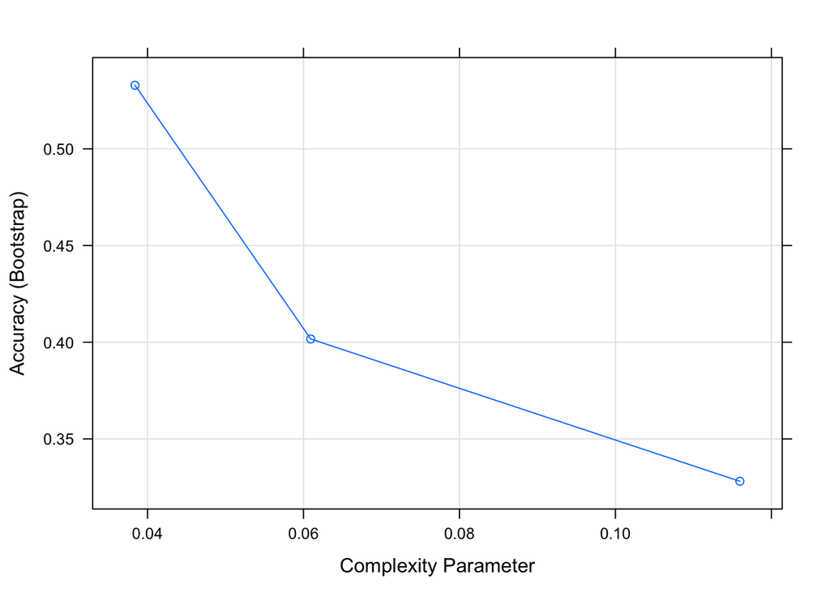

```r
#Build the tree
mod.rpart <- train(classe ~., data = df.train, method = "rpart")
plot(mod.rpart)
```

```r
#Predict using decision tree
pred.rpart <- predict(mod.rpart, df.test)
result.rpart <- confusionMatrix(pred.rpart, df.test$classe)
result.rpart
```

```
## Confusion Matrix and Statistics
##
##           Reference
## Prediction    A    B    C    D    E
##          A 1525  484  499  423  153
##          B   29  385   37  187  159
##          C  116  270  490  354  289
##          D    0    0    0    0    0
##          E    4    0    0    0  481
##
## Overall Statistics
##
##                Accuracy : 0.4895
##                  95% CI : (0.4767, 0.5024)
##     No Information Rate : 0.2845
##     P-Value [Acc > NIR] : < 2.2e-16
##
##                   Kappa : 0.3324
##
##  Mcnemar's Test P-Value : NA
##
## Statistics by Class:
##
##                      Class: A Class: B Class: C Class: D Class: E
## Sensitivity            0.9110  0.33802  0.47758   0.0000  0.44455
## Specificity            0.6298  0.91319  0.78823   1.0000  0.99917
## Pos Pred Value         0.4945  0.48306  0.32258      NaN  0.99175
## Neg Pred Value         0.9468  0.85181  0.87723   0.8362  0.88870
## Prevalence             0.2845  0.19354  0.17434   0.1638  0.18386
## Detection Rate         0.2591  0.06542  0.08326   0.0000  0.08173
## Detection Prevalence   0.5240  0.13543  0.25811   0.0000  0.08241
## Balanced Accuracy      0.7704  0.62560  0.63291   0.5000  0.72186
```

### Get Result

Lastly, we get predictions for the 20 observations of the original pml-testing.csv using Random Forest modet

```r
pred.validation = predict(rf.fit, testing)
pred.validation
```

```
##  1  2  3  4  5  6  7  8  9 10 11 12 13 14 15 16 17 18 19 20
##  B  A  B  A  A  E  D  B  A  A  B  C  B  A  E  E  A  B  B  B
## Levels: A B C D E
```